# project(dbscan)

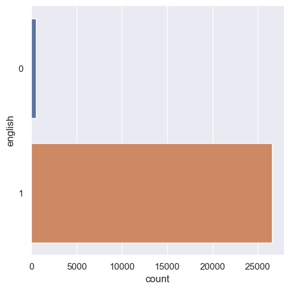

```python
sb.catplot(data=a, y='english', kind='count')
```

```python
# Take the upper limit as the estimate, then log10
a['est_owners'] = a['owners'].str.split('-').map(lambda x: int(x[1])).map(np.log10)
a['est_owners'].value_counts()
```

```
4.30103    18596
4.69897     3059
5.00000     1695
5.30103     1386
5.69897     1272
6.00000      513
6.30103      288
6.69897      193
7.00000       46
7.30103       21
7.69897        3
8.00000        2
8.30103        1
Name: est_owners, dtype: int64
```

```python
fig, ax = plt.subplots(1, 3, figsize=(24,8))
sb.countplot(data=a, y='owners', order=sorted(a['owners'].unique(), key=lambda x: int(x.split('-')[1])), ax=ax[0])
sb.countplot(data=a, y='est_owners', order=a['est_owners'].unique().sort(), ax=ax[1])
sb.violinplot(data=a, x='est_owners', ax=ax[2])
%matplotlib inline
```

[output not shown]

```python
fig, ax = plt.subplots(1, 3, figsize=(24,8))
sb.countplot(data=a, y='owners', order=sorted(a['owners'].unique(), key=lambda x: int(x.split('-')[1])), ax=ax[0])
sb.countplot(data=a, y='est_owners', order=a['est_owners'].unique().sort(), ax=ax[1])
sb.violinplot(data=a, x='est_owners', ax=ax[2])
%matplotlib inline
```

[output not shown]

```python
a[['platforms', 'categories', 'genres', 'steamspy_tags']].tail(1)
```

|  | platforms | categories | genres | steamspy_tags |
| --- | --- | --- | --- | --- |
| 27074 | windows;mac | Single-player;Steam Cloud | Adventure;Casual;Indie | Indie;Casual;Adventure |

```python
def describe_categorical_as_onehot(df: pd.DataFrame, X: pd.Series, keep: "set[str] | 'all'" = None, sep=';'):
  mlb = MultiLabelBinarizer()
  x = mlb.fit_transform(X.str.split(sep)).T
  print(f"Column `{X.name}` has {len(mlb.classes_)} unique labels")
  if keep is not None:
    for i, category in enumerate(mlb.classes_):
      if keep == 'all' or (category in keep):
        df[category] = x[i]
  return mlb.classes_
```

```python
describe_categorical_as_onehot(a, a['platforms'], keep={'windows', 'mac', 'linux'})
```

```
Column `platforms` has 3 unique labels
```

```
array(['linux', 'mac', 'windows'], dtype=object)
```

```python
a[["platforms", "windows", "mac", "linux"]]
```

|  | platforms | windows | mac | linux |
| --- | --- | --- | --- | --- |
| 0 | windows;mac;linux | 1 | 1 | 1 |
| 1 | windows;mac;linux | 1 | 1 | 1 |
| 2 | windows;mac;linux | 1 | 1 | 1 |
| 3 | windows;mac;linux | 1 | 1 | 1 |
| 4 | windows;mac;linux | 1 | 1 | 1 |
| ... | ... | ... | ... | ... |
| 27070 | windows | 1 | 0 | 0 |
| 27071 | windows | 1 | 0 | 0 |
| 27072 | windows | 1 | 0 | 0 |
| 27073 | windows;mac | 1 | 1 | 0 |
| 27074 | windows;mac | 1 | 1 | 0 |

27075 rows × 4 columns

```python
a[['windows', 'mac', 'linux']].sum() / len(a)
```

```
windows    0.999815
mac        0.297913
linux      0.193352
dtype: float64
```

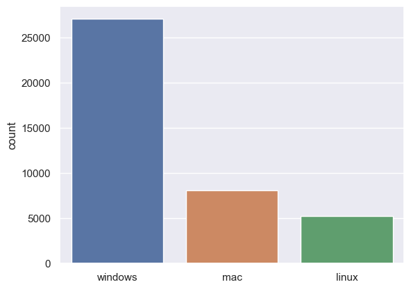

```python
q = a[['windows', 'mac', 'linux']].sum().to_frame(name='count')
sb.barplot(x=q.index, y=q['count'])
```

```python
a['num_categories'] = a['categories'].str.split(';').map(len)
a['num_categories']
```

```
0        4
1        4
2        2
3        4
4        3
        ..
27070    2
27071    1
27072    7
27073    2
27074    2
Name: num_categories, Length: 27075, dtype: int64
```

```python
categories_df = pd.DataFrame(np.arange(0, len(a))).drop(labels=0, axis=1)
describe_categorical_as_onehot(categories_df, a['categories'], keep='all')
```

```
Column `categories` has 29 unique labels
```

```
array(['Captions available', 'Co-op', 'Commentary available',
       'Cross-Platform Multiplayer', 'Full controller support',
       'In-App Purchases', 'Includes Source SDK', 'Includes level editor',
       'Local Co-op', 'Local Multi-Player', 'MMO', 'Mods',
       'Mods (require HL2)', 'Multi-player', 'Online Co-op',
       'Online Multi-Player', 'Partial Controller Support',
       'Shared/Split Screen', 'Single-player', 'Stats',
       'Steam Achievements', 'Steam Cloud', 'Steam Leaderboards',
       'Steam Trading Cards', 'Steam Turn Notifications',
       'Steam Workshop', 'SteamVR Collectibles', 'VR Support',
       'Valve Anti-Cheat enabled'], dtype=object)
```

```python
pd.concat([a, categories_df], axis=1)
```

|  | appid | name | release_date | english | developer | publisher | platforms | required_age | categories | genres | ... | Stats | Steam Achievements | Steam Cloud | Steam Leaderboards | Steam Trading Cards | Steam Turn Notifications | Steam Workshop | SteamVR Collectibles | VR Support | Valve Anti-Cheat enabled |
| --- | --- | --- | --- | --- | --- | --- | --- | --- | --- | --- | --- | --- | --- | --- | --- | --- | --- | --- | --- | --- | --- |
| 0 | 10 | Counter-Strike | 2000-11-01 | 1 | Valve | Valve | windows;mac;linux | 0 | Multi-player;Online Multi-Player;Local Multi-P... | Action | ... | 0 | 0 | 0 | 0 | 0 | 0 | 0 | 0 | 0 | 1 |
| 1 | 20 | Team Fortress Classic | 1999-04-01 | 1 | Valve | Valve | windows;mac;linux | 0 | Multi-player;Online Multi-Player;Local Multi-P... | Action | ... | 0 | 0 | 0 | 0 | 0 | 0 | 0 | 0 | 0 | 1 |
| 2 | 30 | Day of Defeat | 2003-05-01 | 1 | Valve | Valve | windows;mac;linux | 0 | Multi-player;Valve Anti-Cheat enabled | Action | ... | 0 | 0 | 0 | 0 | 0 | 0 | 0 | 0 | 0 | 1 |
| 3 | 40 | Deathmatch Classic | 2001-06-01 | 1 | Valve | Valve | windows;mac;linux | 0 | Multi-player;Online Multi-Player;Local Multi-P... | Action | ... | 0 | 0 | 0 | 0 | 0 | 0 | 0 | 0 | 0 | 1 |
| 4 | 50 | Half-Life: Opposing Force | 1999-11-01 | 1 | Gearbox Software | Valve | windows;mac;linux | 0 | Single-player;Multi-player;Valve Anti-Cheat en... | Action | ... | 0 | 0 | 0 | 0 | 0 | 0 | 0 | 0 | 0 | 1 |
| ... | ... | ... | ... | ... | ... | ... | ... | ... | ... | ... | ... | ... | ... | ... | ... | ... | ... | ... | ... | ... | ... |
| 27070 | 1065230 | Room of Pandora | 2019-04-24 | 1 | SHEN JIAWEI | SHEN JIAWEI | windows | 0 | Single-player;Steam Achievements | Adventure;Casual;Indie | ... | 0 | 1 | 0 | 0 | 0 | 0 | 0 | 0 | 0 | 0 |
| 27071 | 1065570 | Cyber Gun | 2019-04-23 | 1 | Semyon Maximov | BekkerDev Studio | windows | 0 | Single-player | Action;Adventure;Indie | ... | 0 | 0 | 0 | 0 | 0 | 0 | 0 | 0 | 0 | 0 |
| 27072 | 1065650 | Super Star Blast | 2019-04-24 | 1 | EntwicklerX | EntwicklerX | windows | 0 | Single-player;Multi-player;Co-op;Shared/Split ... | Action;Casual;Indie | ... | 0 | 1 | 1 | 0 | 0 | 0 | 0 | 0 | 0 | 0 |
| 27073 | 1066700 | New Yankee 7: Deer Hunters | 2019-04-17 | 1 | Yustas Game Studio | Alawar Entertainment | windows;mac | 0 | Single-player;Steam Cloud | Adventure;Casual;Indie | ... | 0 | 0 | 1 | 0 | 0 | 0 | 0 | 0 | 0 | 0 |
| 27074 | 1069460 | Rune Lord | 2019-04-24 | 1 | Adept Studios GD | Alawar Entertainment | windows;mac | 0 | Single-player;Steam Cloud | Adventure;Casual;Indie | ... | 0 | 0 | 1 | 0 | 0 | 0 | 0 | 0 | 0 | 0 |

27075 rows × 53 columns

```python
categories_df
```

|  | Captions available | Co-op | Commentary available | Cross-Platform Multiplayer | Full controller support | In-App Purchases | Includes Source SDK | Includes level editor | Local Co-op | Local Multi-Player | ... | Stats | Steam Achievements | Steam Cloud | Steam Leaderboards | Steam Trading Cards | Steam Turn Notifications | Steam Workshop | SteamVR Collectibles | VR Support | Valve Anti-Cheat enabled |
| --- | --- | --- | --- | --- | --- | --- | --- | --- | --- | --- | --- | --- | --- | --- | --- | --- | --- | --- | --- | --- | --- |
| 0 | 0 | 0 | 0 | 0 | 0 | 0 | 0 | 0 | 0 | 1 | ... | 0 | 0 | 0 | 0 | 0 | 0 | 0 | 0 | 0 | 1 |
| 1 | 0 | 0 | 0 | 0 | 0 | 0 | 0 | 0 | 0 | 1 | ... | 0 | 0 | 0 | 0 | 0 | 0 | 0 | 0 | 0 | 1 |
| 2 | 0 | 0 | 0 | 0 | 0 | 0 | 0 | 0 | 0 | 0 | ... | 0 | 0 | 0 | 0 | 0 | 0 | 0 | 0 | 0 | 1 |
| 3 | 0 | 0 | 0 | 0 | 0 | 0 | 0 | 0 | 0 | 1 | ... | 0 | 0 | 0 | 0 | 0 | 0 | 0 | 0 | 0 | 1 |
| 4 | 0 | 0 | 0 | 0 | 0 | 0 | 0 | 0 | 0 | 0 | ... | 0 | 0 | 0 | 0 | 0 | 0 | 0 | 0 | 0 | 1 |
| ... | ... | ... | ... | ... | ... | ... | ... | ... | ... | ... | ... | ... | ... | ... | ... | ... | ... | ... | ... | ... | ... |
| 27070 | 0 | 0 | 0 | 0 | 0 | 0 | 0 | 0 | 0 | 0 | ... | 0 | 1 | 0 | 0 | 0 | 0 | 0 | 0 | 0 | 0 |
| 27071 | 0 | 0 | 0 | 0 | 0 | 0 | 0 | 0 | 0 | 0 | ... | 0 | 0 | 0 | 0 | 0 | 0 | 0 | 0 | 0 | 0 |
| 27072 | 0 | 1 | 0 | 0 | 1 | 0 | 0 | 0 | 0 | 0 | ... | 0 | 1 | 1 | 0 | 0 | 0 | 0 | 0 | 0 | 0 |
| 27073 | 0 | 0 | 0 | 0 | 0 | 0 | 0 | 0 | 0 | 0 | ... | 0 | 0 | 1 | 0 | 0 | 0 | 0 | 0 | 0 | 0 |
| 27074 | 0 | 0 | 0 | 0 | 0 | 0 | 0 | 0 | 0 | 0 | ... | 0 | 0 | 1 | 0 | 0 | 0 | 0 | 0 | 0 | 0 |

27075 rows × 29 columns

```python
categories_df[['Single-player', 'Multi-player']]
```

|  | Single-player | Multi-player |
| --- | --- | --- |
| 0 | 0 | 1 |
| 1 | 0 | 1 |
| 2 | 0 | 1 |
| 3 | 0 | 1 |
| 4 | 1 | 1 |
| ... | ... | ... |
| 27070 | 1 | 0 |
| 27071 | 1 | 0 |
| 27072 | 1 | 1 |
| 27073 | 1 | 0 |
| 27074 | 1 | 0 |

27075 rows × 2 columns

```python
(categories_df.sum() / len(categories_df)).sort_values(ascending=False).head(10)
```

```
Single-player                 0.948403
Steam Achievements            0.521884
Steam Trading Cards           0.292447
Steam Cloud                   0.266630
Full controller support       0.210342
Partial Controller Support    0.156380
Multi-player                  0.146777
Steam Leaderboards            0.127018
Online Multi-Player           0.091856
Shared/Split Screen           0.079483
dtype: float64
```

```python
# pearson's correlation does not work for categorical data. only continuous data.
# sb.heatmap(categories_df.corr(), vmin=-1, vmax=1, linewidths=1, cmap="RdBu", annot=True, fmt='.2f', ax=plt.subplots(1,1,figsize=(24,20))[1], square=True)
sb.catplot(a, x='num_categories', kind='count')
```

[output not shown]

```python
a['num_categories'].describe()
```

```
count    27075.000000
mean         3.313980
std          2.235836
min          1.000000
25%          2.000000
50%          3.000000
75%          4.000000
max         18.000000
Name: num_categories, dtype: float64
```

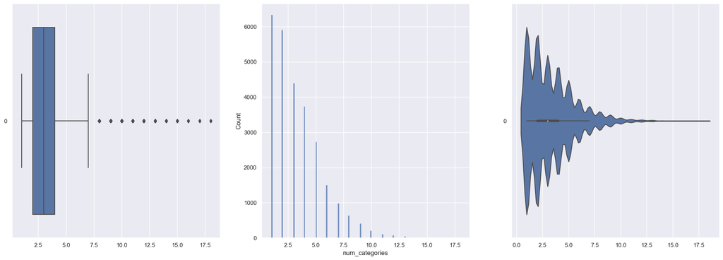

```python
fig, ax = plt.subplots(1,3, figsize=(24, 8))
sb.boxplot(data=a['num_categories'], orient='h', ax=ax[0])

sb.histplot(data=a['num_categories'], ax=ax[1])

sb.violinplot(data=a['num_categories'], orient='h', ax=ax[2])
```

```python
a[a['num_categories'] > 7]['num_categories'].value_counts()
```

```
8     634
9     407
10    204
11    111
12     73
13     46
14     14
15     10
16      5
17      2
18      2
Name: num_categories, dtype: int64
```

```python
a[a['num_categories'] > 15].sort_values(by='est_owners')
```

|  | appid | name | release_date | english | developer | publisher | platforms | required_age | categories | genres | ... | average_playtime | median_playtime | owners | price | year | est_owners | linux | mac | windows | num_categories |
| --- | --- | --- | --- | --- | --- | --- | --- | --- | --- | --- | --- | --- | --- | --- | --- | --- | --- | --- | --- | --- | --- |
| 5574 | 368180 | Polyball | 2017-12-01 | 1 | Studio Monolith | Studio Monolith | windows;mac;linux | 0 | Single-player;Multi-player;Online Multi-Player... | Action;Casual;Indie;Racing;Simulation | ... | 0 | 0 | 0-20000 | 10.99 | 2017 | 4.30103 | 1 | 1 | 1 | 17 |
| 7410 | 420900 | Mech Anarchy | 2016-03-15 | 1 | Trevor Madge | Trevor Madge | windows | 0 | Single-player;Multi-player;Online Multi-Player... | Action;Indie;Early Access | ... | 0 | 0 | 0-20000 | 5.79 | 2016 | 4.30103 | 0 | 0 | 1 | 18 |
| 8440 | 451600 | CounterAttack | 2019-03-11 | 1 | Relative Games | Relative Games | windows;mac;linux | 0 | Single-player;Multi-player;Online Multi-Player... | Action;Adventure;Indie | ... | 0 | 0 | 0-20000 | 11.39 | 2019 | 4.30103 | 1 | 1 | 1 | 18 |
| 13583 | 600440 | Cyber Complex | 2017-08-04 | 1 | PolarityFlow;Adrian Zingg | PolarityFlow | windows;linux | 0 | Single-player;Multi-player;Online Multi-Player... | Action;Casual;Indie;Simulation;Strategy | ... | 13 | 13 | 0-20000 | 6.99 | 2017 | 4.30103 | 1 | 0 | 1 | 16 |
| 2503 | 273500 | Over 9000 Zombies! | 2015-02-25 | 1 | Loren Lemcke | Loren Lemcke | windows | 0 | Single-player;Multi-player;Online Multi-Player... | Action;Indie | ... | 17 | 17 | 100000-200000 | 1.59 | 2015 | 5.30103 | 0 | 0 | 1 | 16 |
| 3651 | 314970 | Age of Conquest IV | 2016-04-05 | 1 | Noble Master LLC | Noble Master LLC | windows;mac;linux | 0 | Single-player;Multi-player;Online Multi-Player... | Free to Play;Indie;Strategy | ... | 93 | 141 | 200000-500000 | 0.00 | 2016 | 5.69897 | 1 | 1 | 1 | 16 |
| 4724 | 346330 | BrainBread 2 | 2016-07-20 | 1 | Reperio Studios | Reperio Studios | windows;mac;linux | 0 | Single-player;Multi-player;Online Multi-Player... | Action;Adventure;Free to Play;Indie;Early Access | ... | 46 | 43 | 1000000-2000000 | 0.00 | 2016 | 6.30103 | 1 | 1 | 1 | 17 |
| 780 | 41070 | Serious Sam 3: BFE | 2011-11-22 | 1 | Croteam | Devolver Digital | windows;mac;linux | 0 | Single-player;Multi-player;Online Multi-Player... | Action;Indie | ... | 378 | 215 | 2000000-5000000 | 29.99 | 2011 | 6.69897 | 1 | 1 | 1 | 16 |
| 1764 | 238460 | BattleBlock Theater® | 2014-05-15 | 1 | The Behemoth | The Behemoth | windows;mac;linux | 0 | Single-player;Multi-player;Online Multi-Player... | Action;Adventure;Casual;Indie | ... | 774 | 289 | 2000000-5000000 | 10.99 | 2014 | 6.69897 | 1 | 1 | 1 | 16 |

9 rows × 24 columns

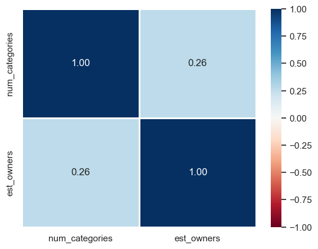

```python
sb.heatmap(a[['num_categories', 'est_owners']].corr(), vmin=-1, vmax=1, linewidths=1, cmap="RdBu", annot=True, fmt='.2f')
```

```python
a['num_genres'] = a['genres'].str.split(';').map(len)
a['num_genres']
```

```
0        1
1        1
2        1
3        1
4        1
        ..
27070    3
27071    3
27072    3
27073    3
27074    3
Name: num_genres, Length: 27075, dtype: int64
```

```python
genres_df = pd.DataFrame(np.arange(0, len(a))).drop(labels=0, axis=1)
describe_categorical_as_onehot(genres_df, a['genres'], keep='all')
```

```
Column `genres` has 29 unique labels
```

```
array(['Accounting', 'Action', 'Adventure', 'Animation & Modeling',
       'Audio Production', 'Casual', 'Design & Illustration',
       'Documentary', 'Early Access', 'Education', 'Free to Play',
       'Game Development', 'Gore', 'Indie', 'Massively Multiplayer',
       'Nudity', 'Photo Editing', 'RPG', 'Racing', 'Sexual Content',
       'Simulation', 'Software Training', 'Sports', 'Strategy',
       'Tutorial', 'Utilities', 'Video Production', 'Violent',
       'Web Publishing'], dtype=object)
```

```python
pd.concat([a, genres_df], axis=1)
```

|  | appid | name | release_date | english | developer | publisher | platforms | required_age | categories | genres | ... | Sexual Content | Simulation | Software Training | Sports | Strategy | Tutorial | Utilities | Video Production | Violent | Web Publishing |
| --- | --- | --- | --- | --- | --- | --- | --- | --- | --- | --- | --- | --- | --- | --- | --- | --- | --- | --- | --- | --- | --- |
| 0 | 10 | Counter-Strike | 2000-11-01 | 1 | Valve | Valve | windows;mac;linux | 0 | Multi-player;Online Multi-Player;Local Multi-P... | Action | ... | 0 | 0 | 0 | 0 | 0 | 0 | 0 | 0 | 0 | 0 |
| 1 | 20 | Team Fortress Classic | 1999-04-01 | 1 | Valve | Valve | windows;mac;linux | 0 | Multi-player;Online Multi-Player;Local Multi-P... | Action | ... | 0 | 0 | 0 | 0 | 0 | 0 | 0 | 0 | 0 | 0 |
| 2 | 30 | Day of Defeat | 2003-05-01 | 1 | Valve | Valve | windows;mac;linux | 0 | Multi-player;Valve Anti-Cheat enabled | Action | ... | 0 | 0 | 0 | 0 | 0 | 0 | 0 | 0 | 0 | 0 |
| 3 | 40 | Deathmatch Classic | 2001-06-01 | 1 | Valve | Valve | windows;mac;linux | 0 | Multi-player;Online Multi-Player;Local Multi-P... | Action | ... | 0 | 0 | 0 | 0 | 0 | 0 | 0 | 0 | 0 | 0 |
| 4 | 50 | Half-Life: Opposing Force | 1999-11-01 | 1 | Gearbox Software | Valve | windows;mac;linux | 0 | Single-player;Multi-player;Valve Anti-Cheat en... | Action | ... | 0 | 0 | 0 | 0 | 0 | 0 | 0 | 0 | 0 | 0 |
| ... | ... | ... | ... | ... | ... | ... | ... | ... | ... | ... | ... | ... | ... | ... | ... | ... | ... | ... | ... | ... | ... |
| 27070 | 1065230 | Room of Pandora | 2019-04-24 | 1 | SHEN JIAWEI | SHEN JIAWEI | windows | 0 | Single-player;Steam Achievements | Adventure;Casual;Indie | ... | 0 | 0 | 0 | 0 | 0 | 0 | 0 | 0 | 0 | 0 |
| 27071 | 1065570 | Cyber Gun | 2019-04-23 | 1 | Semyon Maximov | BekkerDev Studio | windows | 0 | Single-player | Action;Adventure;Indie | ... | 0 | 0 | 0 | 0 | 0 | 0 | 0 | 0 | 0 | 0 |
| 27072 | 1065650 | Super Star Blast | 2019-04-24 | 1 | EntwicklerX | EntwicklerX | windows | 0 | Single-player;Multi-player;Co-op;Shared/Split ... | Action;Casual;Indie | ... | 0 | 0 | 0 | 0 | 0 | 0 | 0 | 0 | 0 | 0 |
| 27073 | 1066700 | New Yankee 7: Deer Hunters | 2019-04-17 | 1 | Yustas Game Studio | Alawar Entertainment | windows;mac | 0 | Single-player;Steam Cloud | Adventure;Casual;Indie | ... | 0 | 0 | 0 | 0 | 0 | 0 | 0 | 0 | 0 | 0 |
| 27074 | 1069460 | Rune Lord | 2019-04-24 | 1 | Adept Studios GD | Alawar Entertainment | windows;mac | 0 | Single-player;Steam Cloud | Adventure;Casual;Indie | ... | 0 | 0 | 0 | 0 | 0 | 0 | 0 | 0 | 0 | 0 |

27075 rows × 54 columns

```python
genres_df
```

|  | Accounting | Action | Adventure | Animation & Modeling | Audio Production | Casual | Design & Illustration | Documentary | Early Access | Education | ... | Sexual Content | Simulation | Software Training | Sports | Strategy | Tutorial | Utilities | Video Production | Violent | Web Publishing |
| --- | --- | --- | --- | --- | --- | --- | --- | --- | --- | --- | --- | --- | --- | --- | --- | --- | --- | --- | --- | --- | --- |
| 0 | 0 | 1 | 0 | 0 | 0 | 0 | 0 | 0 | 0 | 0 | ... | 0 | 0 | 0 | 0 | 0 | 0 | 0 | 0 | 0 | 0 |
| 1 | 0 | 1 | 0 | 0 | 0 | 0 | 0 | 0 | 0 | 0 | ... | 0 | 0 | 0 | 0 | 0 | 0 | 0 | 0 | 0 | 0 |
| 2 | 0 | 1 | 0 | 0 | 0 | 0 | 0 | 0 | 0 | 0 | ... | 0 | 0 | 0 | 0 | 0 | 0 | 0 | 0 | 0 | 0 |
| 3 | 0 | 1 | 0 | 0 | 0 | 0 | 0 | 0 | 0 | 0 | ... | 0 | 0 | 0 | 0 | 0 | 0 | 0 | 0 | 0 | 0 |
| 4 | 0 | 1 | 0 | 0 | 0 | 0 | 0 | 0 | 0 | 0 | ... | 0 | 0 | 0 | 0 | 0 | 0 | 0 | 0 | 0 | 0 |
| ... | ... | ... | ... | ... | ... | ... | ... | ... | ... | ... | ... | ... | ... | ... | ... | ... | ... | ... | ... | ... | ... |
| 27070 | 0 | 0 | 1 | 0 | 0 | 1 | 0 | 0 | 0 | 0 | ... | 0 | 0 | 0 | 0 | 0 | 0 | 0 | 0 | 0 | 0 |
| 27071 | 0 | 1 | 1 | 0 | 0 | 0 | 0 | 0 | 0 | 0 | ... | 0 | 0 | 0 | 0 | 0 | 0 | 0 | 0 | 0 | 0 |
| 27072 | 0 | 1 | 0 | 0 | 0 | 1 | 0 | 0 | 0 | 0 | ... | 0 | 0 | 0 | 0 | 0 | 0 | 0 | 0 | 0 | 0 |
| 27073 | 0 | 0 | 1 | 0 | 0 | 1 | 0 | 0 | 0 | 0 | ... | 0 | 0 | 0 | 0 | 0 | 0 | 0 | 0 | 0 | 0 |
| 27074 | 0 | 0 | 1 | 0 | 0 | 1 | 0 | 0 | 0 | 0 | ... | 0 | 0 | 0 | 0 | 0 | 0 | 0 | 0 | 0 | 0 |

27075 rows × 29 columns

```python
(genres_df.sum() / len(genres_df)).sort_values(ascending=False).head(10)
```

```
Indie           0.717304
Action          0.439631
Casual          0.377101
Adventure       0.370526
Strategy        0.193795
Simulation      0.191837
RPG             0.159224
Early Access    0.109104
Free to Play    0.062936
Sports          0.048827
dtype: float64
```

```python
# pearson's correlation does not work for categorical data. only continuous data.
# sb.heatmap(genres_df.corr(), vmin=-1, vmax=1, linewidths=1, cmap="RdBu", annot=True, fmt='.2f', ax=plt.subplots(1,1,figsize=(24,20))[1], square=True)
sb.catplot(a, x='num_genres', kind='count')
```

[output not shown]

```python
a['num_genres'].describe()
```

```
count    27075.000000
mean         2.824081
std          1.333244
min          1.000000
25%          2.000000
50%          3.000000
75%          4.000000
max         16.000000
Name: num_genres, dtype: float64
```

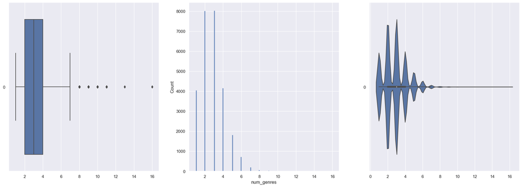

```python
fig, ax = plt.subplots(1,3, figsize=(24, 8))
sb.boxplot(data=a['num_genres'], orient='h', ax=ax[0])

sb.histplot(data=a['num_genres'], ax=ax[1])

sb.violinplot(data=a['num_genres'], orient='h', ax=ax[2])
```

```python
a[a['num_genres'] > 7]['num_genres'].value_counts()
```

```
8     60
9     26
10    12
11     7
13     1
16     1
Name: num_genres, dtype: int64
```

```python
a[a['num_genres'] > 10].sort_values(by='est_owners')
```

|  | appid | name | release_date | english | developer | publisher | platforms | required_age | categories | genres | ... | median_playtime | owners | price | year | est_owners | linux | mac | windows | num_categories | num_genres |
| --- | --- | --- | --- | --- | --- | --- | --- | --- | --- | --- | --- | --- | --- | --- | --- | --- | --- | --- | --- | --- | --- |
| 16768 | 697630 | WARMA | 2018-06-19 | 1 | WARMA Corporation | WARMA Corporation | windows | 0 | Online Multi-Player;MMO | Nudity;Violent;Gore;Action;Adventure;Indie;Mas... | ... | 0 | 0-20000 | 9.29 | 2018 | 4.30103 | 0 | 0 | 1 | 2 | 11 |
| 24494 | 933920 | GIRLS VR UNCENSORED!!! | 2018-09-28 | 1 | Eroticon VR | Eroticon VR | windows | 0 | Single-player | Action;Adventure;Casual;Free to Play;Indie;Mas... | ... | 0 | 0-20000 | 9.29 | 2018 | 4.30103 | 0 | 0 | 1 | 1 | 11 |
| 24515 | 934710 | 英语杀 | 2018-11-04 | 0 | 边玩边学网络科技有限公司 | 边玩边学网络科技有限公司 | windows | 0 | Single-player | Casual;Free to Play;Indie;RPG;Strategy;Account... | ... | 0 | 0-20000 | 0.00 | 2018 | 4.30103 | 0 | 0 | 1 | 1 | 16 |
| 24524 | 934990 | Cute Girls VR | 2018-09-22 | 1 | Tomimar | Tomimar | windows | 0 | Single-player | Action;Adventure;Casual;Free to Play;Indie;Mas... | ... | 0 | 0-20000 | 6.19 | 2018 | 4.30103 | 0 | 0 | 1 | 1 | 11 |
| 25010 | 953610 | HOT GIRLS VR | 2018-10-26 | 1 | tomimar | tomimar | windows | 0 | Single-player | Action;Adventure;Casual;Free to Play;Indie;Mas... | ... | 0 | 0-20000 | 9.29 | 2018 | 4.30103 | 0 | 0 | 1 | 1 | 11 |
| 25118 | 958300 | Cute Girls 可爱的女孩 | 2018-10-21 | 1 | Dance studio mix | Dance studio mix | windows | 0 | Single-player | Action;Adventure;Casual;Free to Play;Indie;Mas... | ... | 0 | 0-20000 | 2.89 | 2018 | 4.30103 | 0 | 0 | 1 | 1 | 11 |
| 25951 | 994320 | Night City 2177 | 2019-02-23 | 1 | Alongini | Alongini | windows | 0 | Single-player | Action;Adventure;Casual;Free to Play;Indie;Mas... | ... | 0 | 0-20000 | 2.89 | 2019 | 4.30103 | 0 | 0 | 1 | 1 | 11 |
| 26957 | 1050150 | Sexy Miss | 2019-04-20 | 1 | Sexy Miss Studio | Sexy Miss Studio | windows | 0 | Single-player | Action;Adventure;Casual;Free to Play;Indie;Mas... | ... | 0 | 0-20000 | 13.99 | 2019 | 4.30103 | 0 | 0 | 1 | 1 | 11 |
| 20466 | 803010 | Supermedium - Virtual Reality Browser | 2018-03-06 | 1 | Supermedium | Supermedium | windows | 0 | Single-player | Casual;Free to Play;Indie;Accounting;Animation... | ... | 0 | 20000-50000 | 0.00 | 2018 | 4.69897 | 0 | 0 | 1 | 1 | 13 |

9 rows × 25 columns

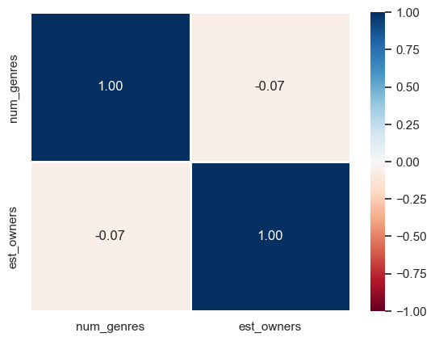

```python
sb.heatmap(a[['num_genres', 'est_owners']].corr(), vmin=-1, vmax=1, linewidths=1, cmap="RdBu", annot=True, fmt='.2f')
```

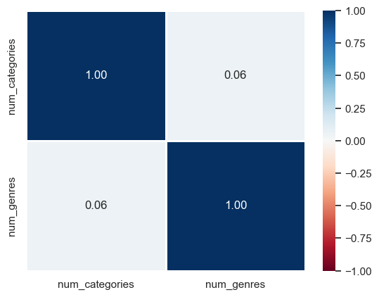

```python
sb.heatmap(a[['num_categories', 'num_genres']].corr(), vmin=-1, vmax=1, linewidths=1, cmap="RdBu", annot=True, fmt='.2f')
```

```python
a['num_steamspy_tags'] = a['steamspy_tags'].str.split(';').map(len)
a['num_steamspy_tags']
```

```
0        3
1        3
2        3
3        3
4        3
        ..
27070    3
27071    3
27072    3
27073    3
27074    3
Name: num_steamspy_tags, Length: 27075, dtype: int64
```

```python
import warnings
warnings.filterwarnings('ignore')
tags_df = pd.DataFrame(np.arange(0, len(a))).drop(labels=0, axis=1)
r = describe_categorical_as_onehot(tags_df, a['steamspy_tags'], keep='all') # this generates a lot of warnings
warnings.filterwarnings('default')
tags_df = tags_df.copy(deep=True)
```

```
Column `steamspy_tags` has 339 unique labels
```

```python
(tags_df.sum() / len(tags_df)).sort_values(ascending=False)
```

```
Indie                             0.599520
Action                            0.381237
Casual                            0.303047
Adventure                         0.286981
Strategy                          0.154127
                                    ...
Investigation                     0.000037
Cinematic                         0.000037
Inventory Management              0.000037
Intentionally Awkward Controls    0.000037
Logic                             0.000037
Length: 339, dtype: float64
```

```python
tags_df.sum().describe()
```

```
count      339.000000
mean       230.094395
std       1258.224753
min          1.000000
25%          4.000000
50%         14.000000
75%         55.000000
max      16232.000000
dtype: float64
```

```python
a['Single-player'] = categories_df['Single-player']
a['Multi-player'] = categories_df['Multi-player']
```

```python
categorical = ['english', 'windows', 'mac', 'linux', 'Single-player', 'Multi-player'] # + list(genres_df.columns)
numerical = ['required_age', 'achievements', 'positive_ratings', 'negative_ratings',
             'average_playtime', 'median_playtime', 'price',
             'year', 'est_owners', 'num_categories', 'num_genres', 'num_steamspy_tags']
scaler = StandardScaler()
X = pd.DataFrame(data=scaler.fit_transform(a.loc[:, numerical]), columns=numerical)
X = pd.concat([a.loc[:, categorical], X], axis=1)
X
```

|  | english | windows | mac | linux | Single-player | Multi-player | required_age | achievements | positive_ratings | negative_ratings | average_playtime | median_playtime | price | year | est_owners | num_categories | num_genres | num_steamspy_tags |
| --- | --- | --- | --- | --- | --- | --- | --- | --- | --- | --- | --- | --- | --- | --- | --- | --- | --- | --- |
| 0 | 1 | 1 | 1 | 1 | 0 | 1 | -0.147507 | -0.128306 | 6.505741 | 0.730006 | 9.557829 | 0.072624 | 0.141186 | -7.648808 | 5.213985 | 0.306835 | -1.368178 | 0.311447 |
| 1 | 1 | 1 | 1 | 1 | 0 | 1 | -0.147507 | -0.128306 | 0.122045 | 0.098480 | 0.069619 | -0.035710 | -0.265175 | -8.112426 | 4.636120 | 0.306835 | -1.368178 | 0.311447 |
| 2 | 1 | 1 | 1 | 1 | 0 | 1 | -0.147507 | -0.128306 | 0.127206 | 0.043636 | 0.020358 | -0.047606 | -0.265175 | -6.257955 | 4.636120 | -0.587702 | -1.368178 | 0.311447 |
| 3 | 1 | 1 | 1 | 1 | 0 | 1 | -0.147507 | -0.128306 | 0.014348 | 0.013063 | 0.059220 | 0.016120 | -0.265175 | -7.185190 | 4.636120 | 0.306835 | -1.368178 | 0.311447 |
| 4 | 1 | 1 | 1 | 1 | 1 | 1 | -0.147507 | -0.128306 | 0.223792 | 0.017964 | 0.259548 | 0.114258 | -0.265175 | -8.112426 | 4.636120 | -0.140433 | -1.368178 | 0.311447 |
| ... | ... | ... | ... | ... | ... | ... | ... | ... | ... | ... | ... | ... | ... | ... | ... | ... | ... | ... |
| 27070 | 1 | 1 | 0 | 0 | 1 | 0 | -0.147507 | -0.108457 | -0.052535 | -0.049249 | -0.081995 | -0.062050 | -0.506452 | 1.159926 | -0.544894 | -0.587702 | 0.131950 | 0.311447 |
| 27071 | 1 | 1 | 0 | 0 | 1 | 0 | -0.147507 | -0.128306 | -0.052272 | -0.049016 | -0.081995 | -0.062050 | -0.557247 | 1.159926 | -0.544894 | -1.034970 | 0.131950 | 0.311447 |
| 27072 | 1 | 1 | 0 | 0 | 1 | 1 | -0.147507 | -0.060252 | -0.052693 | -0.049016 | -0.081995 | -0.062050 | -0.265175 | 1.159926 | -0.544894 | 1.648640 | 0.131950 | 0.311447 |
| 27073 | 1 | 1 | 1 | 0 | 1 | 0 | -0.147507 | -0.128306 | -0.052588 | -0.049249 | -0.081995 | -0.062050 | -0.112790 | 1.159926 | -0.544894 | -0.587702 | 0.131950 | 0.311447 |
| 27074 | 1 | 1 | 1 | 0 | 1 | 0 | -0.147507 | -0.128306 | -0.052483 | -0.049249 | -0.081995 | -0.062050 | -0.112790 | 1.159926 | -0.544894 | -0.587702 | 0.131950 | 0.311447 |

27075 rows × 18 columns

```python
X.columns
```

```
Index(['english', 'windows', 'mac', 'linux', 'Single-player', 'Multi-player',
       'required_age', 'achievements', 'positive_ratings', 'negative_ratings',
       'average_playtime', 'median_playtime', 'price', 'year', 'est_owners',
       'num_categories', 'num_genres', 'num_steamspy_tags'],
      dtype='object')
```

# DBScan

DBSCAN is a density-based clustering algorithm that works on the assumption that clusters are dense regions in space separated by regions of lower density.

It groups ‘densely grouped’ data points into a single cluster.

```python
import numpy as np
import pandas as pd
import os
import matplotlib.pyplot as plt
import seaborn as sns
import warnings
warnings.filterwarnings('ignore')
from sklearn.cluster import DBSCAN
import sklearn.utils
from sklearn.preprocessing import StandardScaler
%matplotlib inline
import numpy as np
from sklearn.decomposition import PCA
from collections import Counter
import numpy as np
from sklearn.cluster import DBSCAN
from sklearn import metrics
```

```python
X
```

|  | english | windows | mac | linux | Single-player | Multi-player | required_age | achievements | positive_ratings | negative_ratings | average_playtime | median_playtime | price | year | est_owners | num_categories | num_genres | num_steamspy_tags |
| --- | --- | --- | --- | --- | --- | --- | --- | --- | --- | --- | --- | --- | --- | --- | --- | --- | --- | --- |
| 0 | 1 | 1 | 1 | 1 | 0 | 1 | -0.147507 | -0.128306 | 6.505741 | 0.730006 | 9.557829 | 0.072624 | 0.141186 | -7.648808 | 5.213985 | 0.306835 | -1.368178 | 0.311447 |
| 1 | 1 | 1 | 1 | 1 | 0 | 1 | -0.147507 | -0.128306 | 0.122045 | 0.098480 | 0.069619 | -0.035710 | -0.265175 | -8.112426 | 4.636120 | 0.306835 | -1.368178 | 0.311447 |
| 2 | 1 | 1 | 1 | 1 | 0 | 1 | -0.147507 | -0.128306 | 0.127206 | 0.043636 | 0.020358 | -0.047606 | -0.265175 | -6.257955 | 4.636120 | -0.587702 | -1.368178 | 0.311447 |
| 3 | 1 | 1 | 1 | 1 | 0 | 1 | -0.147507 | -0.128306 | 0.014348 | 0.013063 | 0.059220 | 0.016120 | -0.265175 | -7.185190 | 4.636120 | 0.306835 | -1.368178 | 0.311447 |
| 4 | 1 | 1 | 1 | 1 | 1 | 1 | -0.147507 | -0.128306 | 0.223792 | 0.017964 | 0.259548 | 0.114258 | -0.265175 | -8.112426 | 4.636120 | -0.140433 | -1.368178 | 0.311447 |
| ... | ... | ... | ... | ... | ... | ... | ... | ... | ... | ... | ... | ... | ... | ... | ... | ... | ... | ... |
| 27070 | 1 | 1 | 0 | 0 | 1 | 0 | -0.147507 | -0.108457 | -0.052535 | -0.049249 | -0.081995 | -0.062050 | -0.506452 | 1.159926 | -0.544894 | -0.587702 | 0.131950 | 0.311447 |
| 27071 | 1 | 1 | 0 | 0 | 1 | 0 | -0.147507 | -0.128306 | -0.052272 | -0.049016 | -0.081995 | -0.062050 | -0.557247 | 1.159926 | -0.544894 | -1.034970 | 0.131950 | 0.311447 |
| 27072 | 1 | 1 | 0 | 0 | 1 | 1 | -0.147507 | -0.060252 | -0.052693 | -0.049016 | -0.081995 | -0.062050 | -0.265175 | 1.159926 | -0.544894 | 1.648640 | 0.131950 | 0.311447 |
| 27073 | 1 | 1 | 1 | 0 | 1 | 0 | -0.147507 | -0.128306 | -0.052588 | -0.049249 | -0.081995 | -0.062050 | -0.112790 | 1.159926 | -0.544894 | -0.587702 | 0.131950 | 0.311447 |
| 27074 | 1 | 1 | 1 | 0 | 1 | 0 | -0.147507 | -0.128306 | -0.052483 | -0.049249 | -0.081995 | -0.062050 | -0.112790 | 1.159926 | -0.544894 | -0.587702 | 0.131950 | 0.311447 |

27075 rows × 18 columns

```python
X.shape
```

```
(27075, 18)
```

First, randomly assigning eps and min samples

```python
# Compute DBSCAN
db = DBSCAN(eps=0.7, min_samples=100).fit(X)
labels = db.labels_


# Number of clusters in labels, ignoring noise if present.
n_clusters_ = len(set(labels)) - (1 if -1 in labels else 0)
n_noise_ = list(labels).count(-1)

print("labels:",labels)
print("no. of clusters:",n_clusters_)
print("no. of noise:",n_noise_)
```

```
labels: [-1 -1 -1 ... -1 11 11]
no. of clusters: 16
no. of noise: 14648
```

```python
np.unique(labels)
```

```
array([-1,  0,  1,  2,  3,  4,  5,  6,  7,  8,  9, 10, 11, 12, 13, 14, 15],
      dtype=int64)
```

```python
#silhouette method
```

The silhouette value is a measure of how similar an object is to its own cluster (cohesion) compared to other clusters (separation). The silhouette ranges from −1 to +1, where a high value indicates that the object is well matched to its own cluster and poorly matched to neighboring clusters. If most objects have a high value, then the clustering configuration is appropriate.

Using silhouette method to check if obtained clusters are optimal on the basis of the parameters provided

```python
print("Estimated number of clusters: %d" % n_clusters_)
print("Estimated number of noise points: %d" % n_noise_)
print(f"Silhouette Coefficient: {metrics.silhouette_score(X, labels):.3f}")
```

```
Estimated number of clusters: 16
Estimated number of noise points: 14648
Silhouette Coefficient: -0.143
```

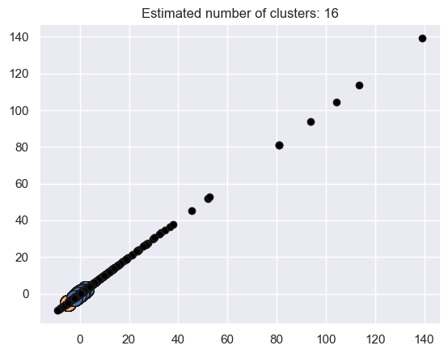

```python
unique_labels = set(labels)
core_samples_mask = np.zeros_like(labels, dtype=bool)
core_samples_mask[db.core_sample_indices_] = True

colors = [plt.cm.Spectral(each) for each in np.linspace(0, 1, len(unique_labels))]
for k, col in zip(unique_labels, colors):
    if k == -1:
        # Black used for noise.
        col = [0, 0, 0, 1]

    class_member_mask = labels == k

    xy = X[class_member_mask & core_samples_mask]
    plt.plot(
        xy,
        xy,
        "o",
        markerfacecolor=tuple(col),
        markeredgecolor="k",
        markersize=14,
    )

    xy = X[class_member_mask & ~core_samples_mask]
    plt.plot(
        xy,
        xy,
        "o",
        markerfacecolor=tuple(col),
        markeredgecolor="k",
        markersize=6,
    )

plt.title(f"Estimated number of clusters: {n_clusters_}")
plt.show()
```

in this case, we have got silhouette coefficient as -0.143 which does not seem appropriate as it is not close to 1 indicating that the clusters we have created are not optimal.A higher silhouette coefficient refers to a model with more coherent clusters

```python
X.shape
```

```
(27075, 18)
```

Usually, the optimal value of min points/samples is twice of features(columns). The number of columns of 'X ' =18 hence let's take min samples/points =36

Now, we know one parameter but we are yet to find optimal value of eps

Using K Nearest Neighbor method to find optimal value of eps

```python
#K Nearest Neighbor
```

```python
import numpy as np
from sklearn.neighbors import NearestNeighbors
nbrs=NearestNeighbors(n_neighbors=36).fit(X)
neigh_dist,neigh_ind=nbrs.kneighbors(X)
sort_neigh_dist=np.sort(neigh_dist,axis=0)
```

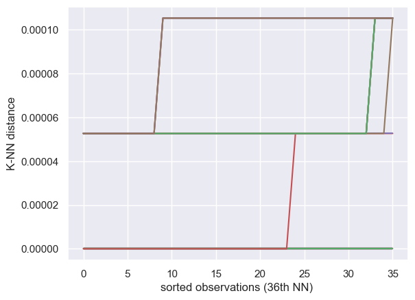

```python
k_dist=sort_neigh_dist[:36]
plt.plot(k_dist)
plt.ylabel("K-NN distance")
plt.xlabel("sorted observations (36th NN) ")
plt.show()
```

```python
neighbors=NearestNeighbors(n_neighbors=36)
neighbors_fit=neighbors.fit(X)
distance,indices=neighbors_fit.kneighbors(X)
```

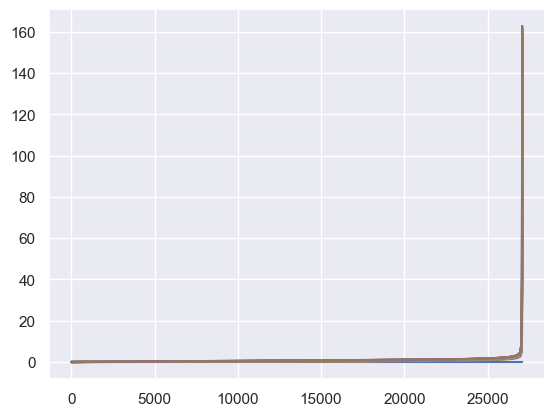

```python
distances=np.sort(distance,axis=0)
distance=distances[:,1]
plt.plot(distances)
```

```python
distances
```

```
array([[0.00000000e+00, 0.00000000e+00, 0.00000000e+00, ...,
        5.26637901e-05, 5.26637901e-05, 5.26637901e-05],
       [0.00000000e+00, 0.00000000e+00, 0.00000000e+00, ...,
        5.26637901e-05, 5.26637901e-05, 5.26637901e-05],
       [0.00000000e+00, 0.00000000e+00, 0.00000000e+00, ...,
        5.26637901e-05, 5.26637901e-05, 5.26637901e-05],
       ...,
       [6.74349576e-07, 5.22514059e+01, 5.22937628e+01, ...,
        1.13495814e+02, 1.13566967e+02, 1.13700484e+02],
       [6.74349576e-07, 8.23835993e+01, 8.30806699e+01, ...,
        1.25283335e+02, 1.25322678e+02, 1.25324786e+02],
       [1.90734863e-06, 1.11771716e+02, 1.14985790e+02, ...,
        1.62621784e+02, 1.62722222e+02, 1.62738767e+02]])
```

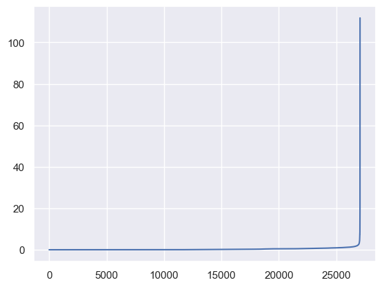

```python
distances=np.sort(distances,axis=0)
distances=distances[:,1]
plt.plot(distances)
```

As we can see through graph , optimal value of eps is somewhere between 5 to 8

```python
#GridSearch
```

Using GridSearch method to find the optimal eps hyperparameter which can work best to find optimal number of clusters

```python
def dbscan_grid_search(X_data, eps_space ,min_samples_space ):#, min_clust = 0, max_clust = 10):

    """
Performs a hyperparameter grid search for DBSCAN.

Parameters:
    * X_data            = data used to fit the DBSCAN instance

    * eps_space         = the range values for the eps parameter
    * min_samples_space = the range values for the min_samples parameter
    * min_clust         = the minimum number of clusters required after each search iteration in order for a result to be appended to the lst
    * max_clust         = the maximum number of clusters required after each search iteration in order for a result to be appended to the lst

Returns

 * lst               = a list to store the results of the grid search
    * clst_count        = a list to store the number of non-whitespace clusters


Example:

# Loading Libraries
from sklearn import datasets
from sklearn.preprocessing import StandardScaler
import pandas as pd

# Loading iris dataset
iris = datasets.load_iris()
X = iris.data[:, :]
y = iris.target

# Scaling X data
dbscan_scaler = StandardScaler()

dbscan_scaler.fit(X)

dbscan_X_scaled = dbscan_scaler.transform(X)

# Setting empty lists in global environment
dbscan_clusters = []
cluster_count   = []


# Inputting function parameters
dbscan_grid_search(X_data = dbscan_X_scaled,
                   lst = dbscan_clusters,
                   clst_count = cluster_count
                   eps_space = pd.np.arange(0.1, 5, 0.1),
                   min_samples_space = pd.np.arange(1, 50, 1),
                   min_clust = 3,
                   max_clust = 6)

"""

    # Importing counter to count the amount of data in each cluster



    # Starting a tally of total iterations
    n_iterations = 0

    clst_count = []
    dbscan_clusters = []

    # Looping over each combination of hyperparameters
    for eps_val in eps_space:
        for samples_val in min_samples_space:

            print("eps : ",eps_val , "| min_sample : ",samples_val  )

            dbscan_grid = DBSCAN(eps = eps_val,
                                 min_samples = samples_val)


            # fit_transform
            clusters = dbscan_grid.fit_predict(X = X_data)
            print(clusters)

            labels = dbscan_grid.labels_
            print("LABELS : ", labels)


            # Counting the amount of data in each cluster
            cluster_count = Counter(clusters)
            print(cluster_count)



            # Saving the number of clusters
            n_clusters = sum(abs(pd.np.unique(clusters))) - 1
            print("n_clusters : ", n_clusters)




            # Increasing the iteration tally with each run of the loop
            n_iterations += 1


            # Appending the lst each time n_clusters criteria is reached
            #if n_clusters >= min_clust and n_clusters <= max_clust:

            sc = sklearn.metrics.silhouette_score(X_data, labels)

            dbscan_clusters.append([eps_val,
                                    samples_val,
                                    n_clusters,sc])
            print("silhouette_score : ", sc)

            clst_count.append(cluster_count)
            print("========================================")


    # Printing grid search summary information

    print(f"""Hyperparameter combinations checked: {n_iterations}. \n""")
    return dbscan_clusters
```